# Bio 381 Webpage

Jorge Ruiz Arocho

2018 M01 17

## Jorge Ruiz Arocho’s Page

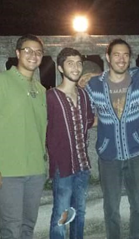

## Introduction

Hey all!

Welcome to my Webpage!

My name is Jorge Alfonso Ruiz-Arocho, I’m a master student at the PSS department and I’m interested on how humans shape environments and its effects on invertebrate communities. Currently, I’m working with crop domestication in Mexico and how this process has shaped the insects biodiversity associated with multiple plant species.

The main purpose of this webpage is to document my progress in the Computational Biology class (Biol 381).

Have fun!

## Helpful Links

- [Course Webpage](https://gotellilab.github.io/Bio381/)
- [RMarkdown Cheatsheet](https://www.rstudio.com/wp-content/uploads/2015/02/rmarkdown-cheatsheet.pdf)
- [Github website templates](https://github.com/jekyll/jekyll/wiki/Themes)
- [R help](http://stackoverflow.com/questions/tagged/r)

## Table of contents of Homework Assignments

- Homework 1: Creation of webpages
- Homework 2: Diagrams made in Typora
- Homework 3: RMarkdown Presentation
- Homework 4: Manipulation of data
- Homework 5: Regular Expressions
- Homework 6: Probability Distributions
- Homework 7: Exploring Hypotheses
- Homework 9: Structured Programming
- Week 10:
- Week 11:

## Homework Solutions and Notes

## Homework 1

https://jorgeruizarocho.github.io/Bio381_2018/

https://github.com/JorgeRuizArocho

## Homework 2

Homework 2 Link

## Homework 3

Homework 3 Link

Clarification: I have been unable to knit to a .pdf file and I’m still unable to create images with a caption overlaid in .html.

## Homework 4

Homework 4 Link

## Homework 5

Homework 5 Link

## Homework 6

Homework 6 Link

## Homework 7

Homework 7 Link

## Homework 9

Homework 9 Link

## Homework 10

Homework 10 Link

## Homework 11

Homework 11 Link